# Genome Visualisation and Annotation

Professor Peter Kille

[figure not shown]

# Requirements

## Data

The data you will need for this exercise are:

1. example genbank or embl files
2. fastq file (pair end or single end data)
3. fasta file representing assembly of data from (1)

## Software

Graphics software (https://sponsa.bios.cf.ac.uk/guacamole/ or install localy)

1. Artemis
2. IGV

Server command line modules (use command `module avail` to check versions):

3. minimap2
4. prokka
5. mitos2
6. NCBI Blast+

# Artemis

## Data

1. Example genbank or embl files

## Software

Artemis - https://www.sanger.ac.uk/tool/artemis/ - can be installed locally (*** http://sanger-pathogens.github.io/Artemis/ Warning this can take time please do not do it during teaching session ***).

We are going to use Artemis using the VNC access to your Linux desktop - go to https://sponsa.bios.cf.ac.uk/guacamole/ and login using your university credentials.

Guacamole Opening Screen

[figure not shown]

Start Terminal

[figure not shown]

Now Load Artemis Module and initiate Artemis with command `art`

```
module load artemis/18.2.0
art
```

Artemis Opening Screen

[figure not shown]

## Workshop

Open Genbank File

```
>File >Open
```

Navigate to your Session3 folder and select the genbank file (`NC_003428.gb`).

[figure not shown]

Cancel any warnings you should see the following window;

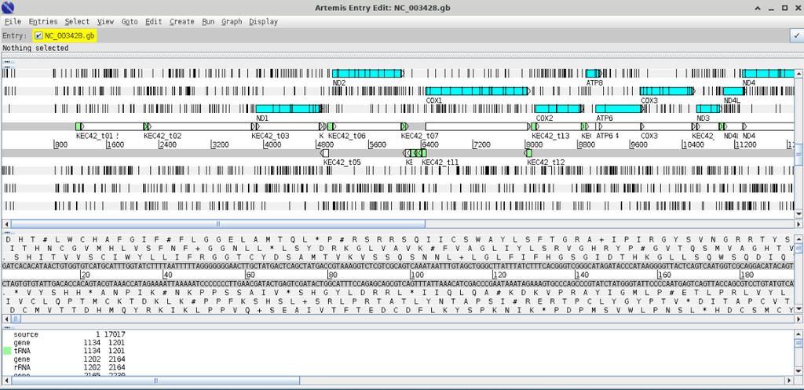

[figure not shown]

Now change the codon table by selecting

```
> Options > Genetic Code Tables
selecet
Vertebrate Mitochondrial
```

Your gene visualisation should now look like this

[figure not shown]

## Excercises

As we look at creating are own annotation you will be able to visual the various outputs using Artemis.

I have included a range of extension exercises / guides generated by Sanmger Centre (the people to wrote Artemis) these are included in you Session Folder under `Artemis_Sanger_Center`

# IGV

## Data

1. Example genbank or embl files

## Software

Integrative Genomics Viewer - https://software.broadinstitute.org/software/igv/ can be installed locally (*** https://software.broadinstitute.org/software/igv/download - Warning this can take time please do not do it during teaching session ***).

We are going to use Artemis using the VNC access to your Linux desktop - go to https://sponsa.bios.cf.ac.uk/guacamole/ and login using your university credentials.

Guacamole Opening Screen

[figure not shown]

Start Terminal

[figure not shown]

Start Terminal

Now Load IGV Module and initiate Artemis with command `igv.sh`

```
module load module load igv/2.12.3
igv.sh
```

IVG Opening Screen

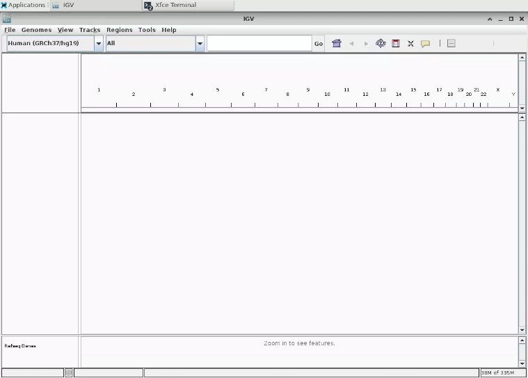

## Workshop

Now open the GenBank file using Genomes

```
> Genomes > Load Genome from File
```

Select GenBank file using file browser - you should see the following image

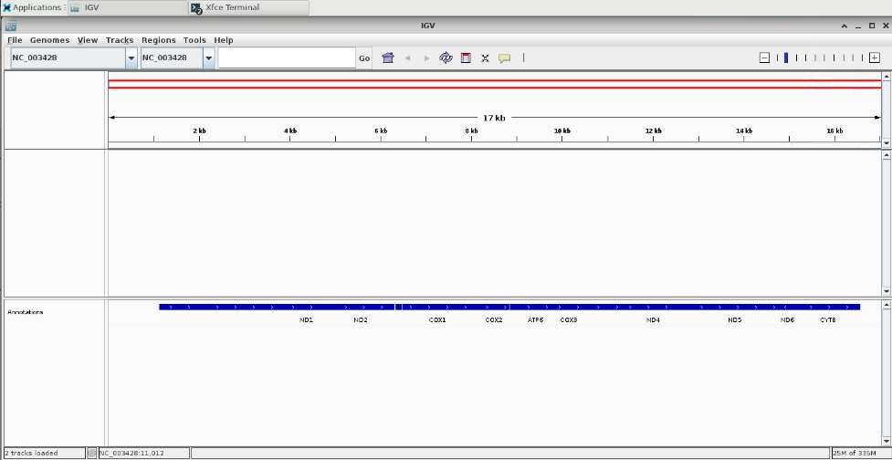

## Excercise

As you generate annotations - look to see how you can overlay them into IVG and also try and visualise the whole bacterial genome and its prokka annotation.

# minimap2

## Data

1. fastq file (pair end or single end data)
2. fasta file representing assembly of data from (1)

## Software

Minimap - mapping software - https://github.com/lh3/minimap2

```
module load minimap2/2.14
```

Samtools - bam/sam tools utilities (for alignment files)

```
module load samtools/1.15.1
```

## Workshop

Align sequences to your assemblies and convert to Bam file

```
minimap2 -ax sr [your contigs.fasta] [forward_read.fastq] [reverse_read.fastq] > aln.sam
samtools view -b -S aln.sam > aln.bam
samtools sort aln.bam > aln_sorted.bam
samtools index aln_sorted.bam
```

## Excersise

Overlay the bam file you have generated into your assembly contig using Artemis and IGV

# Prokka

## Data

1. Sequence reads and assembled genomes (contigs.fasta)

## Software

PROKKA – PREINSTALLED https://github.com/tseemann/prokka

## Workshop

### Prokka

Summary: Prokka is a piece of software that is designed to identify genes from sequence data. It works on prokaryotes. Once it identifies genes, it creates a file including the sequence for the sample, along with a set of annotations to that sequence, which identify the locations of genes.

Basic commands / usage: To run prokka on an assembly (with an example filename of ‘contigs.fa’ use the command:

```
module load prokka_mambaforge/1.14.6
prokka contigs.fa
```

If you want to view the names of output files, you need to provide a name for the files and a directory where they should be saved:

Choose the names of the output files with –outdir and –prefix

```
module load prokka_mambaforge/1.14.6
prokka --outdir mydir --prefix mygenome contigs.fa
```

NOTE: Prokka defaults to analysing Bacteria. Think about what your sample is and what translation table you should use (This is also important for Artemis!). If you’re working on mitochondria include –kingdom mito and the relevant –gcodeSome examples:

- 1. The Standard Code
- 2. The Vertebrate Mitochondrial Code
- 3. The Yeast Mitochondrial Code
- 4. The Invertebrate Mitochondrial Code
- 5. The Echinoderm and Flatworm Mitochondrial Code

A full command for mitochondrial annotation would look like this:

```
module load prokka_mambaforge/1.14.6p

prokka --outdir prokka --kingdom Mitochondria --gcode 2 assembly/contigs.fasta
```

### BARRNAP - BASIC RAPID RIBOSOMAL RNA PREDICTOR

https://github.com/tseemann/barrnap

Summary: Barrnap predicts the location of ribosomal RNA genes in genomes. It supports bacteria (5S,23S,16S), archaea (5S,5.8S,23S,16S), metazoan mitochondria (12S,16S) and eukaryotes (5S,5.8S,28S,18S).

It takes FASTA DNA sequence as input, and write GFF3 as output. It uses the new NHMMER tool that comes with HMMER 3.1 for HMM searching in RNA:DNA style. NHMMER binaries for 64-bit Linux and Mac OS X are included and will be auto-detected. Multithreading is supported and one can expect roughly linear speed-ups with more CPUs.

Basic command Usage:

```
module load barrnap/0.8
barrnap [options] Your_contigs.fasta > outfile.gff
Options:
--help            This help
--version         Print version and exit
--citation        Print citation for referencing barrnap
--kingdom [X]     Kingdom: arc mito euk bac (default 'bac')
--quiet           No screen output (default OFF)
--threads [N]     Number of threads/cores/CPUs to use (default '8')
--lencutoff [n.n] Proportional length threshold to label as partial (default '0.8')
--reject [n.n]    Proportional length threshold to reject prediction (default '0.5')
--evalue [n.n]    Similarity e-value cut-off (default '1e-06')
--incseq          Include FASTA input sequences in GFF3 output (default OFF)
```

## Exercises

### EXERCISE 1:RUNNING PROKKA AND CHECKING ANNOTATIONS

Take your assembled mitochondrial genome, assemble it and run Prokka to annotate the genome. When you have done your visualization introduction you can open this in Artemis.

What do you see as you move along the genome? Are there regions where genes should be that Prokka has not annotated? How would you work out if a gene should be there?

### EXERCISE 2: FIND RIBOSOMAL SEQUENCES IN YOUR DATA

Use barrnap to generate a GFF file predicting the position of any ribosomal sequences – remember to customize the ‘Kingdom’ parameter to reflect the source of the sequence you are using.

# Mitos2

## Data

1. Use the assembled contig from your last session (contigs.fasta)

## Software

mitos2 source: https://gitlab.com/Bernt/MITOS, browser version http://mitos2.bioinf.uni-leipzig.de/index.py

```
module load mitos/2.0.4
```

bioperl-live/release-1-7-2

```
module load bioperl-live/release-1-7-2
```

selectSeqsAboveMinLength

```
~/classdata/Bioinformatics/REFS/script/selectSeqsAboveMinLength.pl
```

bedtools

```
module load bedtools2/2.30.0
```

## Workshop

### Extract largest contig

Use loop to extract out your longest contig - if single contig no need to perfrom this step

```
module load bioperl-live/release-1-7-2
for i in {1..3};do
perl ~/classdata/Bioinformatics/REFS/script/selectSeqsAboveMinLength.pl <your_assembly.fasta> <largest_contig.fasta> 8000
done
```

### Annotate with MITOS2

MITOS is a web server for the automatic annotation of metazoan mitochondrial genomes. MITOS allows a reliable and consistent annotation of proteins and non-coding RNAs. The analysis steps are as follows:

• Candidate protein coding genes are found by detecting congruences in the results of blastx searches against the amino acid sequences of the annotated proteins of metazoan mitochondrial genomes found in the NCBI RefSeq 81. A postprocessing step detects start and stop codons, duplicates, and hits belonging to the same transcript, e.g. frame shift or splicing.

• tRNAs are annotated using MITFI, i.e. novel structure-based covariance models as described in Jühling, et al. Nucleic Acids Research, 2012, 40(7):2833-2845. This approach was shown to have an unmatched sensitivity (outperforming ARWEN and tRNAscan-SE, respectively) and a precision higher than ARWEN and equivalent to tRNAscan-SE.

• rRNA annotation is performed using structure-based covariance # models that have been developed similarly to the tRNA models. Structural considerations improve 5’ and 3’ end predictions of the rRNAs.

• In a final step, conflicts are resolved and the outcome is prepared for visualization.

NB ensure you create you output folder before you run mitos

```
mkdir mitos_annot
runmitos.py  -i contigs.fasta -c 2 -o mitos_annot -R ~/classdata/Bioinformatics/REFS/mitos/ -r refseq81m --rrna 0 --trna 0 --intron 0 --debug --noplot
```

loop would be somethign like this

```
#!/bin/bash

workdir=~/mydata/Session3/

module load mitos/2.0.4

for i in {1..3}; do

mkdir grp${i}_mitos_annot

runmitos.py -i "${workdir}/group${i}_unknown_cetacean_assembly.fasta" \
            -c 2 \
            -o grp${i}_mitos_annot \
            -R ~/classdata/Bioinformatics/REFS/mitos/ \
            -r refseq81m \
            --rrna 0 \
            --trna 0 \
            --intron 0 \
            --debug \
            --noplot

done

module unload mitos/2.0.4
```

### Extract Fasta sequence for genes in Bed file

You can extract the fasta sequence for the genes in the bed file using bedtools getfasta:

```
module load bedtools2/2.30.0
bedtools getfasta –fi contigs.fasta -bed result.bed -name >result.fasta
```

Or using a loop

```
for i in {1..3};
do
bedtools getfasta -fi spades_output_${i}/before_rr.fasta -bed mitos_${i}/result.bed -name >mitos_${i}_result.fasta
done
```

## Excersises

We will now annotate your genome using mitos:

1. Use seqtk seq to select only the largest contig into a new file
2. Use mitos to annotate the contig, and visualize it with Artemis
3. Create a loop to generate the output for all canidiea assembiles
4. [Extension] Use the BEDtools to extract the sequence of the annotated genes
5. [Extension] Use seqtk to extract just the COX1 gene

# NCBI Blast+

## Data

1. Use the assembled contig from your last session (contigs.fasta)
2. Blast Databases, Location:

```
~/classdata/Bioinformatics/REFS/blastdb/
```

• swissprot – uniprot protein database (Uniprot – annotated protein database) • mito_pro – metazoan mitochondrial database • 16S_ribosomal_RNA – 16S ribosomal database

## Software

NCBI Blast+ suite available https://blast.ncbi.nlm.nih.gov/Blast.cgi?PAGE_TYPE=BlastDocs&DOC_TYPE=Download Don’t forget to load the blast and any other modules you need!

```
module load blast-plus/2.12.0
```

## Anatomy of the BLAST command

A basic blast command states your reference database that has been constructed, your query, and an output file: `blastx –db /home/db/fish –query contigs.fasta –out contigs_blx.txt` This uses blastx to match DNA query against protein database. Targets the protein database stored at /home/db/ that’s named ‘fish’. Blast using contig.fasta file and puts the output in contig_blx.txt

## BLAST DATABASES

Currently installed are:

• swissprot – uniprot protein database (Uniprot – annotated protein database) • mito_pro – metazoan mitochondrial database • 16S_ribosomal_RNA – 16S ribosomal database • hum_mt_pep – human mitochondrial

You already have the databases you require today but for reference it is at location

```
 ~/classdata/Bioinformatics/REFS/blastdb/
```

To create blast databases use the makeblastdb. To create a new database:

```
makeblastdb -in nucleotide_seq.fa –dbtype nucl –title my_db -out my_seq
```

## Command line options

```
-in         [input_file]
-dbtype     [molecule_type], nucl – nucleotide or prot - protein
-title  [database_title]
-out        [database_name]
```

OTHER OPTIONS

```
  blastn [-h] [-help] [-import_search_strategy filename]
    [-export_search_strategy filename] [-task task_name] [-db database_name]
    [-dbsize num_letters] [-gilist filename] [-seqidlist filename]
    [-negative_gilist filename] [-negative_seqidlist filename]
    [-taxids taxids] [-negative_taxids taxids] [-taxidlist filename]
    [-negative_taxidlist filename] [-entrez_query entrez_query]
    [-db_soft_mask filtering_algorithm] [-db_hard_mask filtering_algorithm]
    [-subject subject_input_file] [-subject_loc range] [-query input_file]
    [-out output_file] [-evalue evalue] [-word_size int_value]
    [-gapopen open_penalty] [-gapextend extend_penalty]
    [-perc_identity float_value] [-qcov_hsp_perc float_value]
    [-max_hsps int_value] [-xdrop_ungap float_value] [-xdrop_gap float_value]
    [-xdrop_gap_final float_value] [-searchsp int_value] [-penalty penalty]
    [-reward reward] [-no_greedy] [-min_raw_gapped_score int_value]
    [-template_type type] [-template_length int_value] [-dust DUST_options]
    [-filtering_db filtering_database]
    [-window_masker_taxid window_masker_taxid]
    [-window_masker_db window_masker_db] [-soft_masking soft_masking]
    [-ungapped] [-culling_limit int_value] [-best_hit_overhang float_value]
    [-best_hit_score_edge float_value] [-subject_besthit]
    [-window_size int_value] [-off_diagonal_range int_value]
    [-use_index boolean] [-index_name string] [-lcase_masking]
    [-query_loc range] [-strand strand] [-parse_deflines] [-outfmt format]
    [-show_gis] [-num_descriptions int_value] [-num_alignments int_value]
    [-line_length line_length] [-html] [-sorthits sort_hits]
    [-sorthsps sort_hsps] [-max_target_seqs num_sequences]
    [-num_threads int_value] [-remote] [-version]
```

## Exercises

Take your assembled mitochondrial genome and identify mitochondrial orthologues using blast.

1. Perform blastx analysis of your sequence against the mitochondrial protein database. Interrogate the using ‘less’.
2. Re-run the blastx analysis with the output format parameter set to a cutomised `-outfmt 6`, which will output the data into a tablular format compatible with Artemis.

```
blastx -query [contigs.fasta] -db ~/classdata/Bioinformatics/REFS/blastdb/hum_mt_pep -out [output.txt] -outfmt "6 qseqid sseqid pident length mismatch gapopen sstart send qstart qend evalue bitscore"
```

You can now open the fasta sequence you have used in the blast with Artemis and then overlay with the clast output file.

3. Repeat the blastx analysis of your sequence against the mitochondrial protein database [mito_pro] only returning blast matches with an E value lower that 1E-10 and using all 4 threads.
4. Repeat the blastx analysis of your sequence against the mitochondrial protein database, only returning blast matches with an E value lower that 1E-10, using all 4 threads, limiting the outputs so that you keep to 100 and putting the outputs into the tabular format compatible with Artemis.
5. [Extension] Produce a loop to annotate all assembled contigs using blast
6. [Extension] You can try repeating this exercise with swisprot and note the differences